# EEMB146 Lab 4 Exercise

Written by Samantha Sambado

2023-12-29

## Exercise 4 – Comparing Mean with Parametric Tests

# Learning Objectives

- Know how to write **null & alternative hypotheses**
  - and understand what a p-value **< 0.05** or **> 0.05** means for those hypotheses
- Know how to **determine normality**
  - histogram or boxplot
  - qqPlot
  - shapiro-wilk test
- Know how to **test for equal variance**
  - levene Test
- Know which **t-test is the most appropriate** to use
  - one-sample t-test
  - paired t-test
  - two-sample t-test

# Background

It is human nature to compare things, and specifically compare the averages of two different groups (think of comparing the average height of the basketball and soccer teams, or comparing the average speed of cheetahs vs house cats). When we do statistical tests in ecology we often are **comparing the means between two groups**. Because we are interested in the sample means, we need to understand the distribution of these samples.

In Lab 4, we will discuss **t-tests that are appropriate for data that are normal** and in Lab 5, we will dive into which t-tests to use when the data are not normal. Both of these labs will have a lot of background information that should complement the lessons learned in lecture. The **skills learned in Lab 4 and 5 will be a major part of your final project**, hence the length and emphasis on these particular lab exercises and questions.

A major skill in Biometry is **determining normality of the data** (raw or residuals - we’ll get to this more another week). Determining normality involves many tools such as **(1) histrograms/boxplots, (2) qqPlots, (3) Shapiro-Wilk Test**, and **(4) the Central Limit Theorem (CLT)**. You will need to use all of these tools to make an argument for why the data should be considered normal or non-normal. In some instances, 2/4 of your tools will suggest your data are normal, and then you will have to apply your judgement based on what you know about the data you are evaluating. With practice, applying this judgement will get easier.

The reason why we care so much about normality, is because when the **data are normal, then parametric tests can be applied**, which have **higher statistical power** (i.e. low Type II error) than non-parametric tests. Non-parametric tests are not a bad thing, but if you’re able to transform your data to normal then it is strongly recommended to use a parametric test to achieve the most statistical power.

In this lab, we will learn how to determine if our **data distributions are normal** and then apply the **appropriate statistical t-tests** to compare means between groups.

**Note: there is A LOT of information in this lab.** This is because these concepts are some of the **most important concepts you can learn in Biometry**. All of this material may not make sense the first time reading through, but we encourage referencing this document for your midterm and final project

#### The structure for this lab

1. Part 1. **determining normality**
- learn code & concepts for histograms, qqPlots, Shapiro-Wilk Test
2. Part 2. **t-test rules**
- learn the rules for each t-test and how to select for the right one
3. Part 3. **t-test code**
- learn code to run & evaluate t-tests

```r
## setting up the style of your knitted document
knitr::opts_chunk$set(echo = TRUE,message=FALSE, warning=FALSE)

################################################################################
## installing packages
library(readr) # package for reading in data
library(tidyverse) # package for data wrangling
library(ggplot2) # package for plotting
library(cowplot) # package for combining plots
#install.packages("car")
library(car) # NEW package for qqPlots
#install.packages("datarium")
library(datarium) # NEW package for mice data

################################################################################
## upload data
# recommend putting data into a folder called 'data'
titanic <- read.csv("data/titanic.csv")
bumpus <- read.csv("data/natural_selection.csv")
mice <- mice2 # in datarium package

#Data not uploading/getting  error messages? Are your csv  files in your Rproj folder?? Look at your files at the bottom right
```

# Exercises

## Part 1. Determining Normality

### Exercise 1: Determine normality with histograms

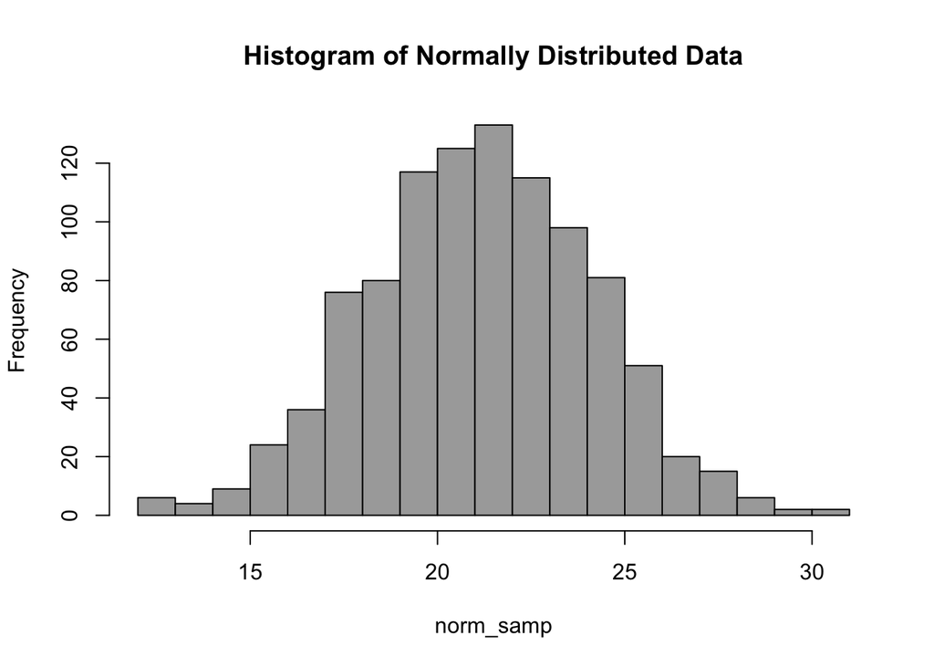

```r
# Generate randomly sampled data to visualize
norm_samp = rnorm(1000, mean=21 , sd=3) #normal distribution
exp_samp = rexp(1000) #exponential distribution

# Visualization with a Histogram
hist(norm_samp,
     breaks=20, #20 bins is more practical, even though our sample size is 10x bigger. You get a sense of how many fall within bins that have a width that makes sense. This normal variable could be "age" for example
     col='darkgray',
     ylab="Frequency",
     main="Histogram of Normally Distributed Data")
```

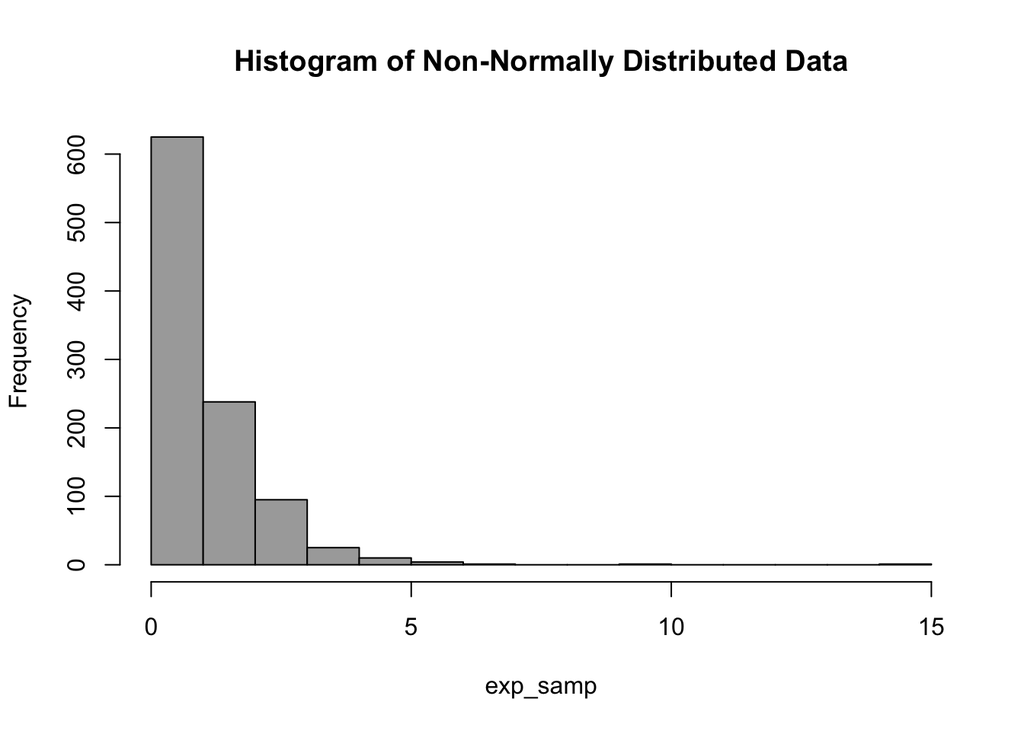

```r
hist(exp_samp,
     breaks=20, #20 bins is more practical, even though our sample size is 10x bigger. You get a sense of how many fall within bins that have a width that makes sense. This normal variable could be "age" for example
     col='darkgray',
     ylab="Frequency",
     main="Histogram of Non-Normally Distributed Data")
```

The `norm_samp` data looks **normally** distributed. The `exp_samp` data does **not look normally** distributed

### Exercise 2: Determine normality with qqPlots

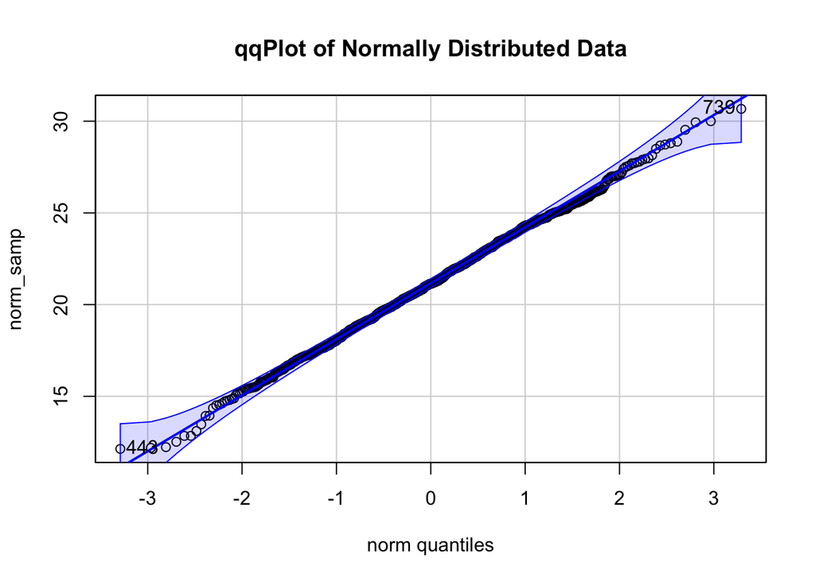

```
## [1] 739 443
```

```r
# Now we’ll generate a qqplot using qqPlot function in car package.
# normal data
qqPlot(norm_samp, main = "qqPlot of Normally Distributed Data") #qqplot function
```

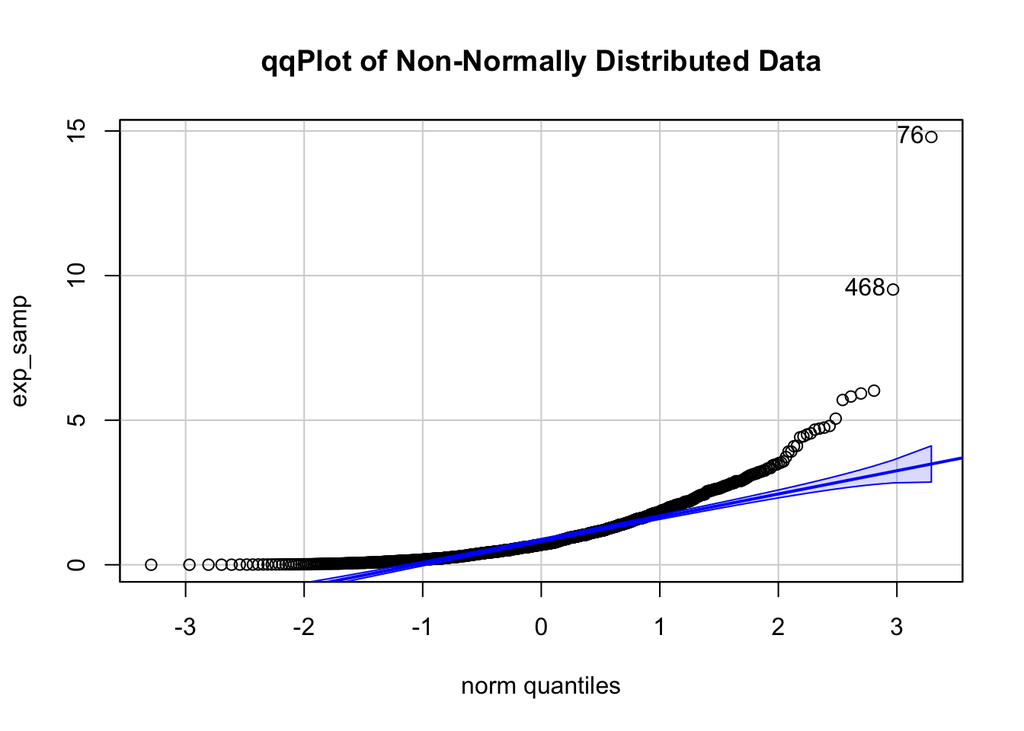

```
## [1]  76 468
```

```r
# non-normal data
qqPlot(exp_samp, main = "qqPlot of Non-Normally Distributed Data") #qqplot function
```

### Exercise 3: Determine normality of data with Shapiro-Wilk Test

**The null hypothesis of this test is that your data are normally distributed**. The alternative hypothesis of this test is that your data are not normally distributed. Therefore, if this test gives us a p-value that is non-significant (i.e. p > 0.05) we can be reasonably confident that our data are normal.

*Memorize this, write this down, get a tattoo of this:*

- p **< 0.05** you can reject the null
- p **> 0.05** you fail to reject the null

Let’s use the Shapiro-Wilk test to see if `norm_samp` is a normal distribution

```r
shapiro.test(norm_samp) #run a shapiro-wilk test on norm_samp
```

```
##
##  Shapiro-Wilk normality test
##
## data:  norm_samp
## W = 0.99879, p-value = 0.7504
```

#### How to interpret shapiro test results

**remember p > 0.05 means you fail to reject the null hypothesis based on your data and tests**

–> This Shapiro-Wilk Test value makes sense since my histogram and qqPlot looked normally distributed

Let’s use the Shapiro-Wilk test to see if `exp_samp` is a normal distribution

```r
shapiro.test(exp_samp) #run a shapiro-wilk test on exp_samp
```

```
##
##  Shapiro-Wilk normality test
##
## data:  exp_samp
## W = 0.73779, p-value < 2.2e-16
```

#### How to interpret shapiro test results

1. **state your p-value**: p-value = < 2.2e-16 (the p-value may be different, but it should be below p < 0.05)
2. **compare your p-value** to significant p-value value: 2.2e-16 < 0.05
3. **look at your null hypothesis**: data are normally distributed
4. **contextualize**: My p-value of the shapiro-wlk test is 2.2e-16, which is below a p-value of 0.05, hence I can be reasonably confident that **my data are not normal**

**remember p < 0.05 means you reject the null hypothesis based on your data and tests**

–> This Shapiro-Wilk value makes sense since my histogram and qqPlot looked not normally distributed

#### Once we have determined if our data are normal, then we can determine an appropriate statistical test to compare means of our data

## Part 2. T-test Rules

### T-test 1: One sample t-test

When we want to ask a question about the mean of a sample, but we **do not know the true variance of the population** (i.e. we have to estimate the variance from the sample) we need to use a **one sample t-test**. The one-sample t-test has the following assumptions:

1. Assumes the test variable (e.g. beak width, kelp height, etc.) has a *normal distribution*
2. Assumes that the observations represent a *random sample* from the population

The **hypotheses** for a **two-sided one sample t-test** are:

- $H_0 : \mu = a$
- $H_A : \mu \neq a$

where $a$ is your hypothesized mean.

To test these hypotheses, **calculate a t statistic** using the following formula:

- $t = \frac{\bar Y - a}{s/\sqrt{n}}$

where $\bar Y$ is the sample mean, $s$ is the standard deviation of your sample, and n is your sample size.

The resulting t-statistic has $n-1$ degrees of freedom (df).

You can **test your null hypothesis** in three different ways:

1. Get the **critical t-value** $(t_{\alpha(2)})$ with $n-1$ df for $\alpha = 0.05$ and compare it to your **calculated t-value**. Reject your null hypothesis if the absolute value of your t-value is greater than the absolute value or the critical t-value.
2. Calculate the **95% confidence interval** with the equation $\bar Y \pm t_{\alpha(2),df}SE_{\bar Y}$ and determine if $a$ (your hypothesized mean) is in the interval. Reject your null hypothesis if $a$ is not in the 95% CI.
3. Find the **p-value associated with your critical t-value** (via R or a t-table with $n-1$ df) and determine if it is less than your predetermined $\alpha$. Reject $H_0$ if $p<\alpha$

R code to calculate a **one sample t-test**

```r
# t.test(DATASET$VARIABLE, mu=MEAN)
```

### T-test 2: Paired t-test

If you want to compare the means between two groups and each data point in one group is uniquely paired with a data point in another group you can use the **paired t-test**. Take the **difference between each pair** of data points and then perform a one sample t-test with $H_0 : \mu_d = 0$. Assumptions:

1. Assumes that the observations from each group represent a *random sample* from the population.
2. Assumes that the *difference* of the two observations follow a *normal distribution*.

R code for **paired t-test**

```r
# t.test(GROUP1, GROUP2, paired = TRUE)
```

### T-test 3: Two sample t-test

The **two-sample t-test** compares whether the means of two groups are significantly different from each other. This test has the following assumptions:

1. Assumes that the observations from *each group* represent a *random sample* from the population.
2. Assumes that the observations follow a *normal distribution*.
3. Assumes that the observations from the two groups have *the same variance*.

If we have two groups called group 1 and group 2, the two-sided hypothesis for the two-sample t-test are:

- $H_0 : \mu_1 = \mu_2$
- $H_A : \mu_1 \neq \mu_2$

Before we can test these hypotheses **we need to ensure that our assumptions are met**.

- You can test the normality assumption using any of the procedures that you already know (e.g. qqplots or the Shapiro-Wilk statistic).
- To test the homogeneity (equal) of variance assumption we will use something called **Levene’s test**. The **null hypothesis** of the Levene’s test is that the **variance between the two groups are equal**. The *alternative hypothesis* is that they are **not equal**. If we fail to reject the *null hypothesis* of the **Levene’s test** we can pool our variances and use a standard two-sample t-test. We would compute this t statistic using the following equations:
  - $SE_{\bar Y_1 - \bar Y_2} = \sqrt{s^2_p(\frac{1}{n_1}+\frac{1}{n_2})}$

where

- $s^2_p = \frac{df_1s^2_1+df_2s^2_2}{df_1+df_2}$

is the pooled sample variance (described in your book). With these equations we can calculate the t statistic:

- $t = \frac{\bar Y_1 - \bar Y_2}{SE_{\bar Y_1 - \bar Y_2}}$

where this t statistic has a df of $n_1 + n_2 - 2$.

If we reject the *null hypothesis* of the Levene’s test we use something called *Welch’s t-test* (which we’ll talk about next week). For now just know that we would prefer our two groups to have equal variance because our statistical test will have more power.

Similar to the one-sample t-test, you can draw conclusions using one of the equivalent methods:

1. Get the **critical t-value** $(t_{\alpha(2)})$ with $n_1 + n_2 - 2$ df (assuming equal variance) for $\alpha = 0.05$ and compare it to your **calculated t-value**. Reject your null hypothesis if your absolute value of your t-value is greater than the absolute value of the critical t-value.
2. Calculate the **5% confidence interval** via the equation $\bar Y_1 - \bar Y_2 \pm SE_{\bar Y_1 - \bar Y_2}t_{\alpha(2),df}$ and determine if 0 is in the interval. Reject your null hypothesis if 0 is not in the 95% CI.
3. Calculate the **p-value associated with your calculated t-value** (via R) and determine if it is less than your predetermined $\alpha$. Reject $H_0$ if $p<\alpha$.

R code

```r
# Two-sampled t-test with equal variances
# t.test(GROUP1$VARIABLE, GROUP2$VARIABLE, var.equal = EQUAL)

# One-sided test: Mean is significantly less of Group 1 than mean of Group 2
# t.test(GROUP1$VARIABLE, GROUP2$VARIABLE, alternative = "less, var.equal = TRUE)
```

## Part 3. T-test code

(i.e. comparing sample means with R code)

### Exercise 4: One sample t-test

Let’s go through an example of how to run a **one-sample t-test** in R. Load in the dataset *titanic.csv*.

This data contains the names, sexes, ages, and fates of all the passengers on the Titanic (search for Jack and Rose if you would like!). We want to ask the following question: **Is the average age of passengers on the Titanic significantly different than 18 years old?**

```r
# Step 0. Explore data
str(titanic) # # 7 variables, 1313 observations
```

```
## 'data.frame':    1313 obs. of  8 variables:
##  $ X               : int  1 2 3 4 5 6 7 8 9 10 ...
##  $ Passenger.Class : chr  "1st" "1st" "1st" "1st" ...
##  $ Name            : chr  "Allen,MissElisabethWalton" "Allison,MissHelenLoraine" "Allison,MrHudsonJoshuaCreighton" "Allison,MrsHudsonJ.C.(BessieWaldoDaniels)" ...
##  $ Age             : num  29 2 30 25 0.917 ...
##  $ Embarked        : chr  "Southampton" "Southampton" "Southampton" "Southampton" ...
##  $ Home.Destination: chr  "StLouis,MO" "Montreal,PQ/Chesterville,ON" "Montreal,PQ/Chesterville,ON" "Montreal,PQ/Chesterville,ON" ...
##  $ Sex             : chr  "female" "female" "male" "female" ...
##  $ Survive         : chr  "yes" "no" "no" "no" ...
```

Let’s go through our steps of checking normality

**Step 1**. Visualize the data. This should always be the first step in data analysis. Make a histogram of all the passenger’s ages. Remember this is what is referred to as *exploratory data analysis* or EDA. We need to visually check what the data look like!

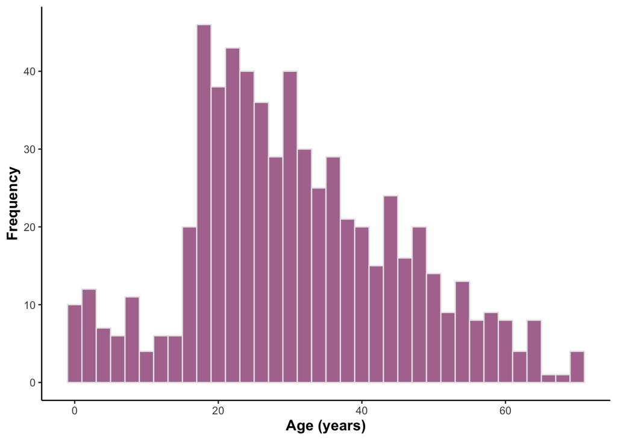

```r
# Step 1. Check normality with a histogram
ggplot(titanic, aes(x = Age)) +
  geom_histogram(binwidth = 2, fill = "#b0779e", color = "grey90")  + # 1 numeric
  theme_classic() +
  labs(x = "Age (years)", y = "Frequency") +
  theme(axis.title = element_text(size = 12, face = "bold")) # looks normal
```

**Step 2**. Visualize the data with a qqPlot.

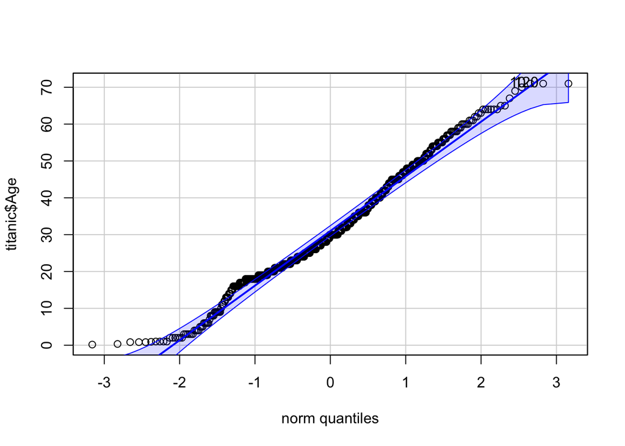

```
## [1]  10 120
```

```r
# Step 2. Check normality with a qqPlot
qqPlot(titanic$Age) # looks normal
```

**Step 3**. Check the assumptions of the single sample t-test: (1) are the data a random sample? and (2) are the ages normally distributed? + We can check (2) using the skills we learned last week (Shapiro-Wilk, $p<0.05$).

```r
# Step 3. Check normality with a Shapiro-Wilk Test
shapiro.test(titanic$Age) # p < 0.05 not normal
```

```
##
##  Shapiro-Wilk normality test
##
## data:  titanic$Age
## W = 0.98264, p-value = 7.771e-07
```

```r
# Step 4. Check if CLT applies
dim(titanic) # over 1,313 observations/rows, CLT applies
```

```
## [1] 1313    8
```

**Step 5**. Based on steps 1-4, we can confidently choose a **one sample t-test**

*Step 5A*. Specify the hypotheses

Specify $H_0 : \mu = 18$ and $H_A : \mu \neq 18$

In words: The **null hypothesis** is that the mean age of passengers on the titanic **are** 18. The **alternative hypothesis** is that the mean age of passengers on the titanic **are not** 18.

*remember: p < 0.05 we reject the null hypothesis, p > 0.05 we fail to reject the null hypothesis*

*Step 5B*. Perform the t-test using R

```r
# Step 5. Chose an appropriate t-test
# Because we are interested if the mean age of 18 is in if individuals were 18 or not 18,
t.test(titanic$Age, mu = 18) # p < 0.05
```

```
##
##  One Sample t-test
##
## data:  titanic$Age
## t = 22.509, df = 632, p-value < 2.2e-16
## alternative hypothesis: true mean is not equal to 18
## 95 percent confidence interval:
##  30.04312 32.34524
## sample estimates:
## mean of x
##  31.19418
```

*Step 5C* From this information we can reject our $H_0$ using **three equivalent methods**:  
(1) Get the **critical two-sided t-value** for $\alpha = 0.05$ and $df = 632$:

```r
# getting the critical two-sided t-value for alpha = 0.05 and df = 632
# df = 632 came from the output of the t.test above
qt(0.025, 632) # self-check: why 0.025 and not 0.05?
```

```
## [1] -1.963725
```

2. Look at the **95% confidence interval** generated from the one sample t-test. Because this interval does not include 18 we can reject our null hypothesis at $\alpha=0.05$.
3. Our exact **p-value** is $p<2.22e^{-16}$ which tells us the probability of getting a result as extreme or more extreme than $\bar Y = 31.19$ years old under our null hypothesis that $\mu = 18$. We can reject our null hypothesis on this critera.

**Step 6. Conclude**. **We can conclude that the mean age of passengers on the Titanic was significantly greater than 18 years old!**

### Exercise 5: Paired t-test

The data `mice` come from the package `datarium` and contains the weight (g) of 10 mice before and after treatment. Because you are comparing the difference of the same mouse before and after treatment, a **paired t-test** is appropriate to run if the normality assumptions are met

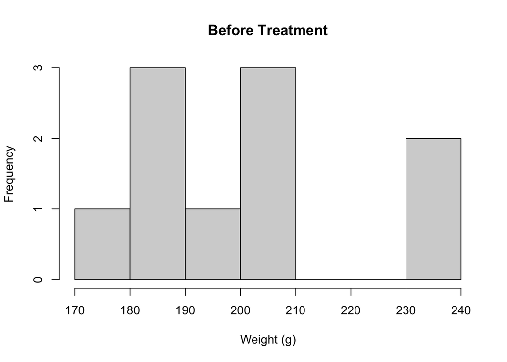

```r
# Step 1. Format data to make analysis easier. This is an example of converting data from wide to long format.
mice_copy <- mice %>% # use mice data and then
  gather(key = "group", value = "weight", before, after) # create column group which will have two levels before & after, create another column called weight which is where the values will go

# Step 2. Create sub-groups of data
before <- mice_copy %>%
  filter(group == "before")

after <- mice_copy %>%
  filter(group == "after")

# Step 3. Visualize normality w/ histograms
hist(before$weight, main = "Before Treatment", xlab = "Weight (g)")
```

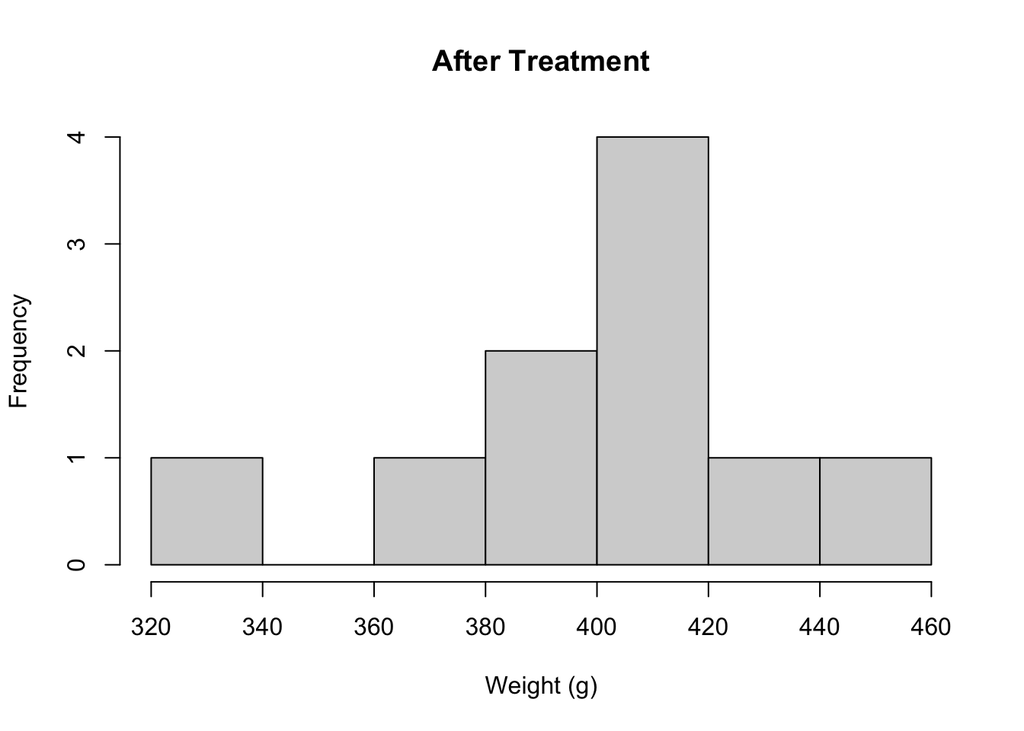

```r
hist(after$weight, main = "After Treatment", xlab = "Weight (g)")
```

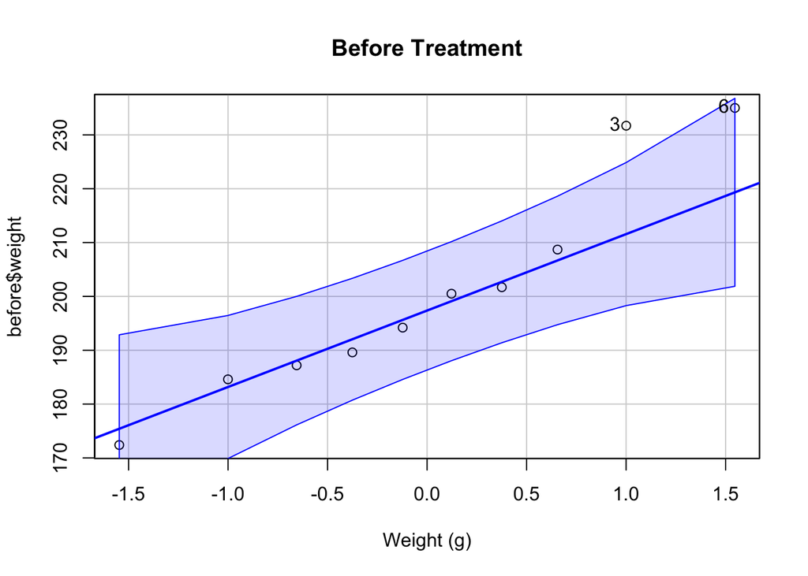

```
## [1] 6 3
```

```r
# Step 4. Visualize normality w/ qqPlots
qqPlot(before$weight, main = "Before Treatment", xlab = "Weight (g)")
```

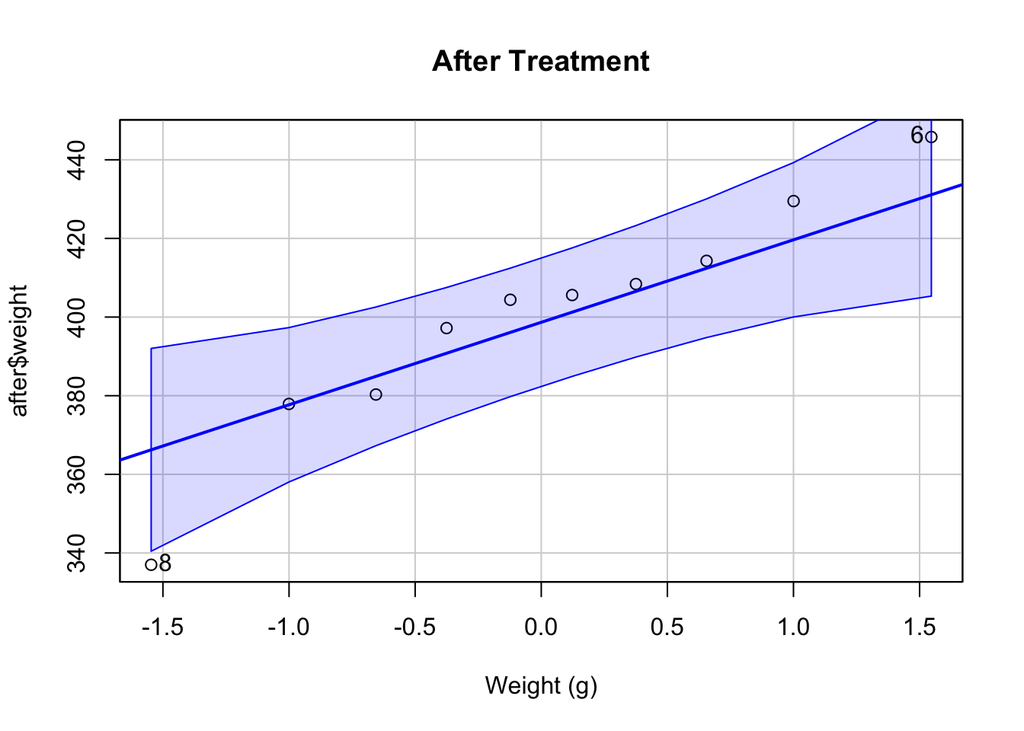

```
## [1] 8 6
```

```r
qqPlot(after$weight, main = "After Treatment", xlab = "Weight (g)")
```

```r
# Step 5. Test normality w/ Shapiro-Wilk Test
shapiro.test(before$weight) # p > 0.05
```

```
##
##  Shapiro-Wilk normality test
##
## data:  before$weight
## W = 0.92399, p-value = 0.3914
```

```r
shapiro.test(after$weight) # p > 0.05
```

```
##
##  Shapiro-Wilk normality test
##
## data:  after$weight
## W = 0.95283, p-value = 0.7021
```

```r
# Step 6. Since normality was met in steps 3-5, and we know we are testing the differences of the same individual, paired t-test is appropriate
t.test(before$weight, after$weight, paired = TRUE) # must include argument paired = TRUE to get credit for assignments
```

```
##
##  Paired t-test
##
## data:  before$weight and after$weight
## t = -25.546, df = 9, p-value = 1.039e-09
## alternative hypothesis: true mean difference is not equal to 0
## 95 percent confidence interval:
##  -217.1442 -181.8158
## sample estimates:
## mean difference
##         -199.48
```

**Step 7**. Interpret paired-test results (check your understanding)

1. state your hypotheses
2. state your p-value
3. evaluate if you reject or fail to reject the H0
4. look at the 95% CI
5. check if the mean difference is equal to 0
6. based on the tests findings, can you support if there is a significant difference in the weight of mice before & after treatment?

### Exercise 6: Two sample t-test

In 1898, Hermon Bumpus collected data on one of the first examples of natural selection directly observed in nature. Immediately following a bad winter storm, 136 English house sparrows were collected and brought indoors. Of these, 72 subsequently recovered, but 64 died :(. Bumpus made several measurements on all of the birds, and he was able to demonstrate strong natural selection on some of the traits as a result of this storm!

Bumpus published all of his data, and you can find them in the file *bumpus.csv*. Test whether the birds that *survived or died* (survival) differed in *total length* (total_length_mm). We can test this using a **two-sample t-test** and the following procedure:

**Step 1**. Format data

```r
survived <- bumpus %>%
  filter(survival == "yes")

died <-  bumpus %>%
  filter(survival == "no")
```

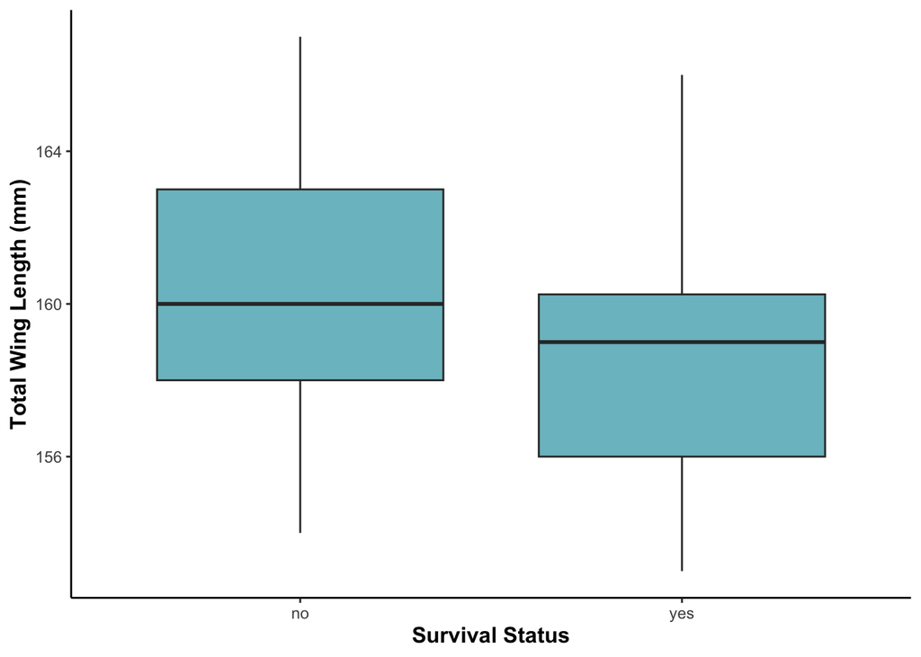

```r
ggplot(bumpus, # you could visualize individual groups (survived or died), but the whole dataset is easier
       aes(x = survival, y = total_length_mm)) + # remember always put your outcome of interest (Y) on the y-axis
  geom_boxplot(fill = "#7bbfc9") + # 1 numeric, 1 factor = boxplot
  theme_classic() +
  labs(x = "Survival Status", y = "Total Wing Length (mm)") +
  theme(axis.title = element_text(size = 12, face = "bold"))
```

**Step 2**. Visulize the data with qqPlot

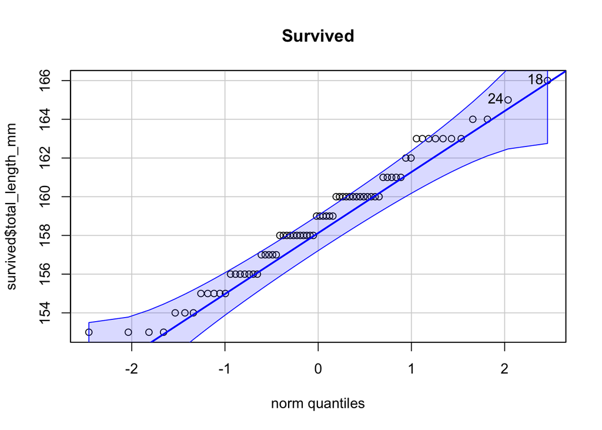

```
## [1] 18 24
```

```r
qqPlot(survived$total_length_mm, main = "Survived") # looks normal
```

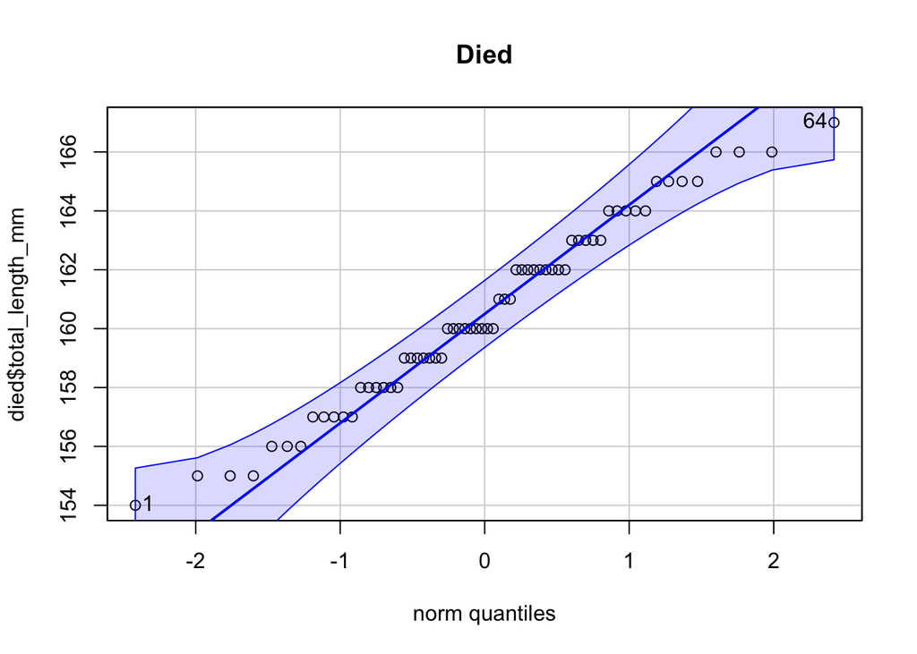

```
## [1]  1 64
```

```r
qqPlot(died$total_length_mm, main = "Died") # looks normal
```

**Step 3**. Test normality with Shapiro-Wilk Test *make sure you understand how to interpret these p-values with the hypotheses of the Shapiro-Wilk Test*

```r
shapiro.test(survived$total_length_mm) # p > 0.05 normal
```

```
##
##  Shapiro-Wilk normality test
##
## data:  survived$total_length_mm
## W = 0.97577, p-value = 0.1787
```

```r
shapiro.test(died$total_length_mm) # p > 0.05 normal
```

```
##
##  Shapiro-Wilk normality test
##
## data:  died$total_length_mm
## W = 0.97655, p-value = 0.262
```

**Step 4**. **New Skill** Test for equal variances using the **Levene’s Test**

Remember: The *null hypothesis* of the Levene’s test is that the **variance between the two groups are equal**. The *alternative hypothesis* is that they are **not equal**.

If p < 0.05 we **reject** the null hypothesis, if p > 0.05 we **fail to reject** the null hypothesis

```r
# Levene's test: (response variable, group variable)
leveneTest(bumpus$total_length_mm, bumpus$survival) # p > 0.05 equal
```

```
## Levene's Test for Homogeneity of Variance (center = median)
##        Df F value Pr(>F)
## group   1  0.1243  0.725
##       134
```

Notice that $p=0.725$. We therefore **fail to reject** our null hypothesis that the variances are equal. Hence, the groups have **equal variances**.

**Step 5**. Because in Step 1-3 we determined the **data are normal** and in Step 4 we determined **variances are equal** between groups, we can appropriately run a **two-sample t-test** (paramtric)

We are testing the difference in means between the group that survived and the group that died. In your homework/midterm you will need to specify this as

- $H_0 : \mu_{survive} = \mu_{died}$
- $H_A : \mu_{survive} \neq \mu_{died}$

```r
t.test(survived$total_length_mm, died$total_length_mm, #response variable, group variable
       var.equal = TRUE) # to get credit on HW you must include this argument var.equal = TRUE, if Levene test < 0.05 then this argument would be set to FALSE
```

```
##
##  Two Sample t-test
##
## data:  survived$total_length_mm and died$total_length_mm
## t = -3.3772, df = 134, p-value = 0.0009588
## alternative hypothesis: true difference in means is not equal to 0
## 95 percent confidence interval:
##  -2.8904907 -0.7553427
## sample estimates:
## mean of x mean of y
##  158.7083  160.5312
```

**Step 6**. Interpret two-sample t-test results (check your understanding)

```r
t.test(survived$total_length_mm, died$total_length_mm, var.equal = TRUE,
       alternative="less") # here, we specify the one-sided "less" hypothesis, since two-sided is the default setting and we want to override that.
```

```
##
##  Two Sample t-test
##
## data:  survived$total_length_mm and died$total_length_mm
## t = -3.3772, df = 134, p-value = 0.0004794
## alternative hypothesis: true difference in means is less than 0
## 95 percent confidence interval:
##        -Inf -0.9288906
## sample estimates:
## mean of x mean of y
##  158.7083  160.5312
```

# Additional Resources for Final Project

For your Final Project, you will be responsible for creating a professional looking report about a biological system you investigated using statistical tests and R skills you learned throughout EEMB 146. Some additional skills that will be of use to manipulate data to determine if your data are normal include

- [transforming data into the right format](https://mgimond.github.io/ES218/tidyr.html) – wide to long visa versa
- [Coercing data from one type to anoter](https://mgimond.github.io/ES218/data_objects.html#coercing-data-from-one-type-to-another) – tips for why it may not be working
- [Still confused about qqPlots?](https://mgimond.github.io/ES218/theoretical_qq.html) – here’s some visual guides

# Vocab

There is A LOT going on in this lab but as one of the most fundamental labs of the quarter it is especially important you understand the following concepts

- **types of statistical test**
  - parametric : use when data meet assumptions of test, have higher statistical power
  - non-parametric : typically when data are not normal & don’t meet parametric assumptions
- **general hypothesis testing**
  - p < 0.05 –> reject the null
  - p > 0.05 –> fail to reject the null
- **specific hypothesis for each new skill**
  - Shapiro-Wilk’s test (testing normality)
  - Levene’s test (testing variance)
  - T-test (comparison of means)
- **t-tests assumptions**
  - one-sample: must be normally distributed
  - paired : must be normally distributed
  - two-sample (parametric): must be normally distributed and have equal variances
- **data format**
  - wide = (generally) more columns than rows
  - long = (generally) more rows than columns

### End of Exercise 4